# Risk Factor Analysis

## Outcome Variable

**Outcome Variable:** y_rate_wtkg

## Predictor Variables

**Intervention Variable:** predexfd6

**Adjustment Set:**

unadjusted

## Stratifying Variables

The analysis was stratified on these variable(s):

- agecat
- studyid
- country

## Data Summary

| agecat | studyid | country | predexfd6 | n_cell | n |
| --- | --- | --- | --- | --- | --- |
| 0-3 months | CMC-V-BCS-2002 | INDIA | 1 | 16 | 16 |
| 0-3 months | CMC-V-BCS-2002 | INDIA | 0 | 0 | 16 |
| 0-3 months | EE | PAKISTAN | 1 | 35 | 39 |
| 0-3 months | EE | PAKISTAN | 0 | 4 | 39 |
| 0-3 months | GMS-Nepal | NEPAL | 1 | 368 | 501 |
| 0-3 months | GMS-Nepal | NEPAL | 0 | 133 | 501 |
| 0-3 months | IRC | INDIA | 1 | 0 | 14 |
| 0-3 months | IRC | INDIA | 0 | 14 | 14 |
| 0-3 months | JiVitA-3 | BANGLADESH | 1 | 9439 | 12206 |
| 0-3 months | JiVitA-3 | BANGLADESH | 0 | 2767 | 12206 |
| 0-3 months | JiVitA-4 | BANGLADESH | 1 | 1506 | 1793 |
| 0-3 months | JiVitA-4 | BANGLADESH | 0 | 287 | 1793 |
| 0-3 months | Keneba | GAMBIA | 1 | 474 | 1491 |
| 0-3 months | Keneba | GAMBIA | 0 | 1017 | 1491 |
| 0-3 months | MAL-ED | BANGLADESH | 1 | 84 | 230 |
| 0-3 months | MAL-ED | BANGLADESH | 0 | 146 | 230 |
| 0-3 months | MAL-ED | BRAZIL | 1 | 30 | 210 |
| 0-3 months | MAL-ED | BRAZIL | 0 | 180 | 210 |
| 0-3 months | MAL-ED | INDIA | 1 | 11 | 216 |
| 0-3 months | MAL-ED | INDIA | 0 | 205 | 216 |
| 0-3 months | MAL-ED | NEPAL | 1 | 11 | 219 |
| 0-3 months | MAL-ED | NEPAL | 0 | 208 | 219 |
| 0-3 months | MAL-ED | PERU | 1 | 92 | 270 |
| 0-3 months | MAL-ED | PERU | 0 | 178 | 270 |
| 0-3 months | MAL-ED | SOUTH AFRICA | 1 | 3 | 234 |
| 0-3 months | MAL-ED | SOUTH AFRICA | 0 | 231 | 234 |
| 0-3 months | MAL-ED | TANZANIA, UNITED REPUBLIC OF | 1 | 1 | 219 |
| 0-3 months | MAL-ED | TANZANIA, UNITED REPUBLIC OF | 0 | 218 | 219 |
| 0-3 months | PROVIDE | BANGLADESH | 1 | 159 | 640 |
| 0-3 months | PROVIDE | BANGLADESH | 0 | 481 | 640 |

[output cut: 226 more lines]

The following strata were considered:

- agecat: 0-3 months, studyid: CMC-V-BCS-2002, country: INDIA
- agecat: 0-3 months, studyid: EE, country: PAKISTAN
- agecat: 0-3 months, studyid: GMS-Nepal, country: NEPAL
- agecat: 0-3 months, studyid: IRC, country: INDIA
- agecat: 0-3 months, studyid: JiVitA-3, country: BANGLADESH
- agecat: 0-3 months, studyid: JiVitA-4, country: BANGLADESH
- agecat: 0-3 months, studyid: Keneba, country: GAMBIA
- agecat: 0-3 months, studyid: MAL-ED, country: BANGLADESH
- agecat: 0-3 months, studyid: MAL-ED, country: BRAZIL
- agecat: 0-3 months, studyid: MAL-ED, country: INDIA
- agecat: 0-3 months, studyid: MAL-ED, country: NEPAL
- agecat: 0-3 months, studyid: MAL-ED, country: PERU
- agecat: 0-3 months, studyid: MAL-ED, country: SOUTH AFRICA
- agecat: 0-3 months, studyid: MAL-ED, country: TANZANIA, UNITED REPUBLIC OF
- agecat: 0-3 months, studyid: PROVIDE, country: BANGLADESH
- agecat: 0-3 months, studyid: SAS-CompFeed, country: INDIA
- agecat: 12-15 months, studyid: CMC-V-BCS-2002, country: INDIA
- agecat: 12-15 months, studyid: EE, country: PAKISTAN
- agecat: 12-15 months, studyid: GMS-Nepal, country: NEPAL
- agecat: 12-15 months, studyid: IRC, country: INDIA
- agecat: 12-15 months, studyid: JiVitA-4, country: BANGLADESH
- agecat: 12-15 months, studyid: Keneba, country: GAMBIA
- agecat: 12-15 months, studyid: LCNI-5, country: MALAWI
- agecat: 12-15 months, studyid: MAL-ED, country: BANGLADESH
- agecat: 12-15 months, studyid: MAL-ED, country: BRAZIL
- agecat: 12-15 months, studyid: MAL-ED, country: INDIA
- agecat: 12-15 months, studyid: MAL-ED, country: NEPAL
- agecat: 12-15 months, studyid: MAL-ED, country: PERU
- agecat: 12-15 months, studyid: MAL-ED, country: SOUTH AFRICA
- agecat: 12-15 months, studyid: MAL-ED, country: TANZANIA, UNITED REPUBLIC OF
- agecat: 12-15 months, studyid: PROVIDE, country: BANGLADESH
- agecat: 12-15 months, studyid: SAS-CompFeed, country: INDIA
- agecat: 12-15 months, studyid: SAS-FoodSuppl, country: INDIA
- agecat: 15-18 months, studyid: CMC-V-BCS-2002, country: INDIA
- agecat: 15-18 months, studyid: EE, country: PAKISTAN
- agecat: 15-18 months, studyid: GMS-Nepal, country: NEPAL
- agecat: 15-18 months, studyid: IRC, country: INDIA
- agecat: 15-18 months, studyid: JiVitA-4, country: BANGLADESH
- agecat: 15-18 months, studyid: Keneba, country: GAMBIA
- agecat: 15-18 months, studyid: LCNI-5, country: MALAWI
- agecat: 15-18 months, studyid: MAL-ED, country: BANGLADESH
- agecat: 15-18 months, studyid: MAL-ED, country: BRAZIL
- agecat: 15-18 months, studyid: MAL-ED, country: INDIA
- agecat: 15-18 months, studyid: MAL-ED, country: NEPAL
- agecat: 15-18 months, studyid: MAL-ED, country: PERU
- agecat: 15-18 months, studyid: MAL-ED, country: SOUTH AFRICA
- agecat: 15-18 months, studyid: MAL-ED, country: TANZANIA, UNITED REPUBLIC OF
- agecat: 15-18 months, studyid: PROVIDE, country: BANGLADESH
- agecat: 15-18 months, studyid: SAS-CompFeed, country: INDIA
- agecat: 15-18 months, studyid: SAS-FoodSuppl, country: INDIA
- agecat: 18-21 months, studyid: CMC-V-BCS-2002, country: INDIA
- agecat: 18-21 months, studyid: EE, country: PAKISTAN
- agecat: 18-21 months, studyid: GMS-Nepal, country: NEPAL
- agecat: 18-21 months, studyid: IRC, country: INDIA
- agecat: 18-21 months, studyid: Keneba, country: GAMBIA
- agecat: 18-21 months, studyid: LCNI-5, country: MALAWI
- agecat: 18-21 months, studyid: MAL-ED, country: BANGLADESH
- agecat: 18-21 months, studyid: MAL-ED, country: BRAZIL
- agecat: 18-21 months, studyid: MAL-ED, country: INDIA
- agecat: 18-21 months, studyid: MAL-ED, country: NEPAL
- agecat: 18-21 months, studyid: MAL-ED, country: PERU
- agecat: 18-21 months, studyid: MAL-ED, country: SOUTH AFRICA
- agecat: 18-21 months, studyid: MAL-ED, country: TANZANIA, UNITED REPUBLIC OF
- agecat: 18-21 months, studyid: PROVIDE, country: BANGLADESH
- agecat: 21-24 months, studyid: CMC-V-BCS-2002, country: INDIA
- agecat: 21-24 months, studyid: EE, country: PAKISTAN
- agecat: 21-24 months, studyid: GMS-Nepal, country: NEPAL
- agecat: 21-24 months, studyid: IRC, country: INDIA
- agecat: 21-24 months, studyid: Keneba, country: GAMBIA
- agecat: 21-24 months, studyid: LCNI-5, country: MALAWI
- agecat: 21-24 months, studyid: MAL-ED, country: BANGLADESH
- agecat: 21-24 months, studyid: MAL-ED, country: BRAZIL
- agecat: 21-24 months, studyid: MAL-ED, country: INDIA
- agecat: 21-24 months, studyid: MAL-ED, country: NEPAL
- agecat: 21-24 months, studyid: MAL-ED, country: PERU
- agecat: 21-24 months, studyid: MAL-ED, country: SOUTH AFRICA
- agecat: 21-24 months, studyid: MAL-ED, country: TANZANIA, UNITED REPUBLIC OF
- agecat: 21-24 months, studyid: PROVIDE, country: BANGLADESH
- agecat: 3-6 months, studyid: CMC-V-BCS-2002, country: INDIA
- agecat: 3-6 months, studyid: EE, country: PAKISTAN
- agecat: 3-6 months, studyid: GMS-Nepal, country: NEPAL
- agecat: 3-6 months, studyid: IRC, country: INDIA
- agecat: 3-6 months, studyid: JiVitA-3, country: BANGLADESH
- agecat: 3-6 months, studyid: JiVitA-4, country: BANGLADESH
- agecat: 3-6 months, studyid: Keneba, country: GAMBIA
- agecat: 3-6 months, studyid: MAL-ED, country: BANGLADESH
- agecat: 3-6 months, studyid: MAL-ED, country: BRAZIL
- agecat: 3-6 months, studyid: MAL-ED, country: INDIA
- agecat: 3-6 months, studyid: MAL-ED, country: NEPAL
- agecat: 3-6 months, studyid: MAL-ED, country: PERU
- agecat: 3-6 months, studyid: MAL-ED, country: SOUTH AFRICA
- agecat: 3-6 months, studyid: MAL-ED, country: TANZANIA, UNITED REPUBLIC OF
- agecat: 3-6 months, studyid: PROVIDE, country: BANGLADESH
- agecat: 3-6 months, studyid: SAS-CompFeed, country: INDIA
- agecat: 6-9 months, studyid: CMC-V-BCS-2002, country: INDIA
- agecat: 6-9 months, studyid: EE, country: PAKISTAN
- agecat: 6-9 months, studyid: GMS-Nepal, country: NEPAL
- agecat: 6-9 months, studyid: IRC, country: INDIA
- agecat: 6-9 months, studyid: JiVitA-4, country: BANGLADESH
- agecat: 6-9 months, studyid: Keneba, country: GAMBIA
- agecat: 6-9 months, studyid: LCNI-5, country: MALAWI
- agecat: 6-9 months, studyid: MAL-ED, country: BANGLADESH
- agecat: 6-9 months, studyid: MAL-ED, country: BRAZIL
- agecat: 6-9 months, studyid: MAL-ED, country: INDIA
- agecat: 6-9 months, studyid: MAL-ED, country: NEPAL
- agecat: 6-9 months, studyid: MAL-ED, country: PERU
- agecat: 6-9 months, studyid: MAL-ED, country: SOUTH AFRICA
- agecat: 6-9 months, studyid: MAL-ED, country: TANZANIA, UNITED REPUBLIC OF
- agecat: 6-9 months, studyid: PROVIDE, country: BANGLADESH
- agecat: 6-9 months, studyid: SAS-CompFeed, country: INDIA
- agecat: 6-9 months, studyid: SAS-FoodSuppl, country: INDIA
- agecat: 9-12 months, studyid: CMC-V-BCS-2002, country: INDIA
- agecat: 9-12 months, studyid: EE, country: PAKISTAN
- agecat: 9-12 months, studyid: GMS-Nepal, country: NEPAL
- agecat: 9-12 months, studyid: IRC, country: INDIA
- agecat: 9-12 months, studyid: JiVitA-4, country: BANGLADESH
- agecat: 9-12 months, studyid: Keneba, country: GAMBIA
- agecat: 9-12 months, studyid: LCNI-5, country: MALAWI
- agecat: 9-12 months, studyid: MAL-ED, country: BANGLADESH
- agecat: 9-12 months, studyid: MAL-ED, country: BRAZIL
- agecat: 9-12 months, studyid: MAL-ED, country: INDIA
- agecat: 9-12 months, studyid: MAL-ED, country: NEPAL
- agecat: 9-12 months, studyid: MAL-ED, country: PERU
- agecat: 9-12 months, studyid: MAL-ED, country: SOUTH AFRICA
- agecat: 9-12 months, studyid: MAL-ED, country: TANZANIA, UNITED REPUBLIC OF
- agecat: 9-12 months, studyid: PROVIDE, country: BANGLADESH
- agecat: 9-12 months, studyid: SAS-CompFeed, country: INDIA
- agecat: 9-12 months, studyid: SAS-FoodSuppl, country: INDIA

### Dropped Strata

Some strata were dropped due to rare outcomes:

- agecat: 0-3 months, studyid: CMC-V-BCS-2002, country: INDIA
- agecat: 0-3 months, studyid: EE, country: PAKISTAN
- agecat: 0-3 months, studyid: IRC, country: INDIA
- agecat: 0-3 months, studyid: MAL-ED, country: SOUTH AFRICA
- agecat: 0-3 months, studyid: MAL-ED, country: TANZANIA, UNITED REPUBLIC OF
- agecat: 3-6 months, studyid: CMC-V-BCS-2002, country: INDIA
- agecat: 3-6 months, studyid: EE, country: PAKISTAN
- agecat: 3-6 months, studyid: IRC, country: INDIA
- agecat: 3-6 months, studyid: MAL-ED, country: SOUTH AFRICA
- agecat: 3-6 months, studyid: MAL-ED, country: TANZANIA, UNITED REPUBLIC OF
- agecat: 6-9 months, studyid: CMC-V-BCS-2002, country: INDIA
- agecat: 6-9 months, studyid: IRC, country: INDIA
- agecat: 6-9 months, studyid: MAL-ED, country: SOUTH AFRICA
- agecat: 6-9 months, studyid: MAL-ED, country: TANZANIA, UNITED REPUBLIC OF
- agecat: 6-9 months, studyid: SAS-FoodSuppl, country: INDIA
- agecat: 9-12 months, studyid: CMC-V-BCS-2002, country: INDIA
- agecat: 9-12 months, studyid: IRC, country: INDIA
- agecat: 9-12 months, studyid: MAL-ED, country: SOUTH AFRICA
- agecat: 9-12 months, studyid: MAL-ED, country: TANZANIA, UNITED REPUBLIC OF
- agecat: 9-12 months, studyid: SAS-FoodSuppl, country: INDIA
- agecat: 12-15 months, studyid: CMC-V-BCS-2002, country: INDIA
- agecat: 12-15 months, studyid: IRC, country: INDIA
- agecat: 12-15 months, studyid: LCNI-5, country: MALAWI
- agecat: 12-15 months, studyid: MAL-ED, country: SOUTH AFRICA
- agecat: 12-15 months, studyid: MAL-ED, country: TANZANIA, UNITED REPUBLIC OF
- agecat: 12-15 months, studyid: SAS-FoodSuppl, country: INDIA
- agecat: 15-18 months, studyid: CMC-V-BCS-2002, country: INDIA
- agecat: 15-18 months, studyid: IRC, country: INDIA
- agecat: 15-18 months, studyid: LCNI-5, country: MALAWI
- agecat: 15-18 months, studyid: MAL-ED, country: SOUTH AFRICA
- agecat: 15-18 months, studyid: MAL-ED, country: TANZANIA, UNITED REPUBLIC OF
- agecat: 15-18 months, studyid: SAS-FoodSuppl, country: INDIA
- agecat: 18-21 months, studyid: CMC-V-BCS-2002, country: INDIA
- agecat: 18-21 months, studyid: IRC, country: INDIA
- agecat: 18-21 months, studyid: MAL-ED, country: SOUTH AFRICA
- agecat: 18-21 months, studyid: MAL-ED, country: TANZANIA, UNITED REPUBLIC OF
- agecat: 21-24 months, studyid: CMC-V-BCS-2002, country: INDIA
- agecat: 21-24 months, studyid: EE, country: PAKISTAN
- agecat: 21-24 months, studyid: IRC, country: INDIA
- agecat: 21-24 months, studyid: MAL-ED, country: SOUTH AFRICA
- agecat: 21-24 months, studyid: MAL-ED, country: TANZANIA, UNITED REPUBLIC OF

## Methods Detail

We’re interested in the causal parameters $E[Y_a]$ for all values of $a \in \mathcal{A}$. These parameters represent the mean outcome if, possibly contrary to fact, we intervened to set all units to have $A=a$. Under the randomization and positivity assumptions, these are identified by the statistical parameters $\psi_a=E_W[E_{Y|A,W}(Y|A=a,W)]$. In addition, we’re interested in the mean of $Y$, $E[Y]$ under no intervention (the observed mean). We will estimate these parameters by using SuperLearner to fit the relevant likelihood factors – $E_{Y|A,W}(Y|A=a,W)$ and $p(A=a|W)$, and then updating our likelihood fit using a joint TMLE.

For unadjusted analyses ($W=\{\}$), initial likelihoods were estimated using Lrnr_glm to estimate the simple $E(Y|A)$ and Lrnr_mean to estimate $p(A)$. For adjusted analyses, a small library containing Lrnr_glmnet, Lrnr_xgboost, and Lrnr_mean was used.

Having estimated these parameters, we will then use the delta method to estimate relative risks and attributable risks relative to a prespecified baseline level of $A$.

# Results Detail

## Results Plots

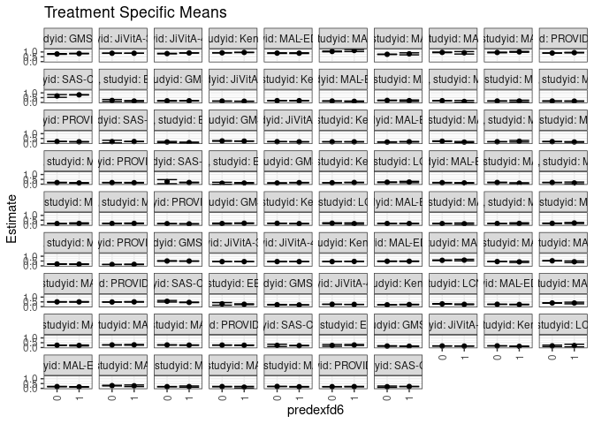

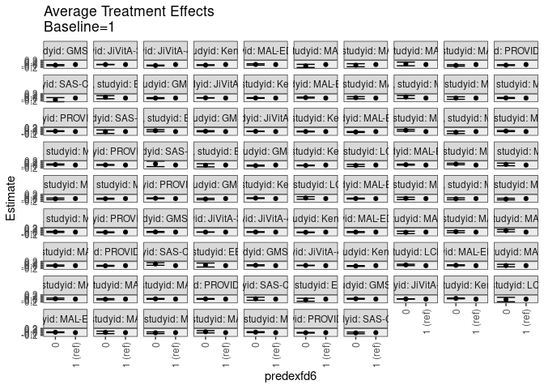

[figure not shown]

## Results Table

### Parameter: TSM

| agecat | studyid | country | intervention_level | baseline_level | estimate | ci_lower | ci_upper |
| --- | --- | --- | --- | --- | --- | --- | --- |
| 0-3 months | GMS-Nepal | NEPAL | 1 | NA | 0.8380598 | 0.8184064 | 0.8577132 |
| 0-3 months | GMS-Nepal | NEPAL | 0 | NA | 0.7935141 | 0.7595044 | 0.8275237 |
| 0-3 months | JiVitA-3 | BANGLADESH | 1 | NA | 0.8697792 | 0.8656341 | 0.8739244 |
| 0-3 months | JiVitA-3 | BANGLADESH | 0 | NA | 0.8711985 | 0.8636326 | 0.8787644 |
| 0-3 months | JiVitA-4 | BANGLADESH | 1 | NA | 0.9005636 | 0.8894245 | 0.9117027 |
| 0-3 months | JiVitA-4 | BANGLADESH | 0 | NA | 0.8331414 | 0.8062009 | 0.8600820 |
| 0-3 months | Keneba | GAMBIA | 1 | NA | 0.9542465 | 0.9353131 | 0.9731799 |
| 0-3 months | Keneba | GAMBIA | 0 | NA | 0.9132900 | 0.8991870 | 0.9273931 |
| 0-3 months | MAL-ED | BANGLADESH | 1 | NA | 0.8785628 | 0.8416938 | 0.9154318 |
| 0-3 months | MAL-ED | BANGLADESH | 0 | NA | 0.8832152 | 0.8515297 | 0.9149007 |
| 0-3 months | MAL-ED | BRAZIL | 1 | NA | 1.1558074 | 1.0486772 | 1.2629375 |
| 0-3 months | MAL-ED | BRAZIL | 0 | NA | 1.0560334 | 1.0200107 | 1.0920561 |
| 0-3 months | MAL-ED | INDIA | 1 | NA | 0.8084220 | 0.7032785 | 0.9135655 |
| 0-3 months | MAL-ED | INDIA | 0 | NA | 0.7590105 | 0.7352261 | 0.7827950 |
| 0-3 months | MAL-ED | NEPAL | 1 | NA | 0.9156871 | 0.7869751 | 1.0443990 |
| 0-3 months | MAL-ED | NEPAL | 0 | NA | 0.9592764 | 0.9310824 | 0.9874703 |
| 0-3 months | MAL-ED | PERU | 1 | NA | 1.0127375 | 0.9713286 | 1.0541465 |
| 0-3 months | MAL-ED | PERU | 0 | NA | 0.9513375 | 0.9188603 | 0.9838147 |
| 0-3 months | PROVIDE | BANGLADESH | 1 | NA | 0.9333255 | 0.9065324 | 0.9601186 |
| 0-3 months | PROVIDE | BANGLADESH | 0 | NA | 0.8911755 | 0.8737543 | 0.9085968 |
| 0-3 months | SAS-CompFeed | INDIA | 1 | NA | 0.7911385 | 0.7734666 | 0.8088105 |
| 0-3 months | SAS-CompFeed | INDIA | 0 | NA | 0.6753966 | 0.5336166 | 0.8171765 |
| 3-6 months | GMS-Nepal | NEPAL | 1 | NA | 0.4938217 | 0.4779042 | 0.5097393 |
| 3-6 months | GMS-Nepal | NEPAL | 0 | NA | 0.5053164 | 0.4771995 | 0.5334333 |
| 3-6 months | JiVitA-3 | BANGLADESH | 1 | NA | 0.4404515 | 0.4362568 | 0.4446462 |
| 3-6 months | JiVitA-3 | BANGLADESH | 0 | NA | 0.4389878 | 0.4306770 | 0.4472985 |
| 3-6 months | JiVitA-4 | BANGLADESH | 1 | NA | 0.4383765 | 0.4286656 | 0.4480874 |
| 3-6 months | JiVitA-4 | BANGLADESH | 0 | NA | 0.4426217 | 0.4215010 | 0.4637424 |
| 3-6 months | Keneba | GAMBIA | 1 | NA | 0.4582618 | 0.4407930 | 0.4757305 |
| 3-6 months | Keneba | GAMBIA | 0 | NA | 0.4421820 | 0.4307660 | 0.4535980 |

[output cut: 144 more lines]

### Parameter: E(Y)

| agecat | studyid | country | intervention_level | baseline_level | estimate | ci_lower | ci_upper |
| --- | --- | --- | --- | --- | --- | --- | --- |
| 0-3 months | GMS-Nepal | NEPAL | NA | NA | 0.8262343 | 0.8091204 | 0.8433482 |
| 0-3 months | JiVitA-3 | BANGLADESH | NA | NA | 0.8701010 | 0.8664010 | 0.8738010 |
| 0-3 months | JiVitA-4 | BANGLADESH | NA | NA | 0.8897715 | 0.8792902 | 0.9002529 |
| 0-3 months | Keneba | GAMBIA | NA | NA | 0.9263104 | 0.9149216 | 0.9376991 |
| 0-3 months | MAL-ED | BANGLADESH | NA | NA | 0.8815161 | 0.8573098 | 0.9057224 |
| 0-3 months | MAL-ED | BRAZIL | NA | NA | 1.0702868 | 1.0355019 | 1.1050717 |
| 0-3 months | MAL-ED | INDIA | NA | NA | 0.7615268 | 0.7382819 | 0.7847718 |
| 0-3 months | MAL-ED | NEPAL | NA | NA | 0.9570869 | 0.9295107 | 0.9846631 |
| 0-3 months | MAL-ED | PERU | NA | NA | 0.9722590 | 0.9463823 | 0.9981357 |
| 0-3 months | PROVIDE | BANGLADESH | NA | NA | 0.9016472 | 0.8868914 | 0.9164029 |
| 0-3 months | SAS-CompFeed | INDIA | NA | NA | 0.7852849 | 0.7678149 | 0.8027549 |
| 3-6 months | GMS-Nepal | NEPAL | NA | NA | 0.4969184 | 0.4830319 | 0.5108048 |
| 3-6 months | JiVitA-3 | BANGLADESH | NA | NA | 0.4401107 | 0.4363074 | 0.4439140 |
| 3-6 months | JiVitA-4 | BANGLADESH | NA | NA | 0.4390246 | 0.4301757 | 0.4478736 |
| 3-6 months | Keneba | GAMBIA | NA | NA | 0.4467297 | 0.4371593 | 0.4563000 |
| 3-6 months | MAL-ED | BANGLADESH | NA | NA | 0.4752798 | 0.4582021 | 0.4923576 |
| 3-6 months | MAL-ED | BRAZIL | NA | NA | 0.5781976 | 0.5469697 | 0.6094254 |
| 3-6 months | MAL-ED | INDIA | NA | NA | 0.4421852 | 0.4242493 | 0.4601211 |
| 3-6 months | MAL-ED | NEPAL | NA | NA | 0.5212498 | 0.5005373 | 0.5419623 |
| 3-6 months | MAL-ED | PERU | NA | NA | 0.4986791 | 0.4796733 | 0.5176848 |
| 3-6 months | PROVIDE | BANGLADESH | NA | NA | 0.4890611 | 0.4760060 | 0.5021163 |
| 3-6 months | SAS-CompFeed | INDIA | NA | NA | 0.4538554 | 0.4355388 | 0.4721719 |
| 6-9 months | EE | PAKISTAN | NA | NA | 0.2545881 | 0.2127069 | 0.2964693 |
| 6-9 months | GMS-Nepal | NEPAL | NA | NA | 0.1872663 | 0.1750716 | 0.1994611 |
| 6-9 months | JiVitA-4 | BANGLADESH | NA | NA | 0.2387113 | 0.2332818 | 0.2441408 |
| 6-9 months | Keneba | GAMBIA | NA | NA | 0.2019457 | 0.1892538 | 0.2146377 |
| 6-9 months | LCNI-5 | MALAWI | NA | NA | 0.2829175 | 0.2578313 | 0.3080037 |
| 6-9 months | MAL-ED | BANGLADESH | NA | NA | 0.2415793 | 0.2267676 | 0.2563910 |
| 6-9 months | MAL-ED | BRAZIL | NA | NA | 0.3831499 | 0.3570859 | 0.4092138 |
| 6-9 months | MAL-ED | INDIA | NA | NA | 0.2373787 | 0.2225426 | 0.2522148 |

[output cut: 57 more lines]

### Parameter: ATE

| agecat | studyid | country | intervention_level | baseline_level | estimate | ci_lower | ci_upper |
| --- | --- | --- | --- | --- | --- | --- | --- |
| 0-3 months | GMS-Nepal | NEPAL | 1 | 1 | 0.0000000 | 0.0000000 | 0.0000000 |
| 0-3 months | GMS-Nepal | NEPAL | 0 | 1 | -0.0445457 | -0.0838257 | -0.0052658 |
| 0-3 months | JiVitA-3 | BANGLADESH | 1 | 1 | 0.0000000 | 0.0000000 | 0.0000000 |
| 0-3 months | JiVitA-3 | BANGLADESH | 0 | 1 | 0.0014193 | -0.0070506 | 0.0098892 |
| 0-3 months | JiVitA-4 | BANGLADESH | 1 | 1 | 0.0000000 | 0.0000000 | 0.0000000 |
| 0-3 months | JiVitA-4 | BANGLADESH | 0 | 1 | -0.0674222 | -0.0965971 | -0.0382473 |
| 0-3 months | Keneba | GAMBIA | 1 | 1 | 0.0000000 | 0.0000000 | 0.0000000 |
| 0-3 months | Keneba | GAMBIA | 0 | 1 | -0.0409565 | -0.0645652 | -0.0173478 |
| 0-3 months | MAL-ED | BANGLADESH | 1 | 1 | 0.0000000 | 0.0000000 | 0.0000000 |
| 0-3 months | MAL-ED | BANGLADESH | 0 | 1 | 0.0046524 | -0.0439613 | 0.0532662 |
| 0-3 months | MAL-ED | BRAZIL | 1 | 1 | 0.0000000 | 0.0000000 | 0.0000000 |
| 0-3 months | MAL-ED | BRAZIL | 0 | 1 | -0.0997740 | -0.2127984 | 0.0132504 |
| 0-3 months | MAL-ED | INDIA | 1 | 1 | 0.0000000 | 0.0000000 | 0.0000000 |
| 0-3 months | MAL-ED | INDIA | 0 | 1 | -0.0494115 | -0.1572116 | 0.0583885 |
| 0-3 months | MAL-ED | NEPAL | 1 | 1 | 0.0000000 | 0.0000000 | 0.0000000 |
| 0-3 months | MAL-ED | NEPAL | 0 | 1 | 0.0435893 | -0.0881744 | 0.1753530 |
| 0-3 months | MAL-ED | PERU | 1 | 1 | 0.0000000 | 0.0000000 | 0.0000000 |
| 0-3 months | MAL-ED | PERU | 0 | 1 | -0.0614000 | -0.1140258 | -0.0087743 |
| 0-3 months | PROVIDE | BANGLADESH | 1 | 1 | 0.0000000 | 0.0000000 | 0.0000000 |
| 0-3 months | PROVIDE | BANGLADESH | 0 | 1 | -0.0421500 | -0.0741089 | -0.0101911 |
| 0-3 months | SAS-CompFeed | INDIA | 1 | 1 | 0.0000000 | 0.0000000 | 0.0000000 |
| 0-3 months | SAS-CompFeed | INDIA | 0 | 1 | -0.1157419 | -0.2637432 | 0.0322594 |
| 3-6 months | GMS-Nepal | NEPAL | 1 | 1 | 0.0000000 | 0.0000000 | 0.0000000 |
| 3-6 months | GMS-Nepal | NEPAL | 0 | 1 | 0.0114946 | -0.0208152 | 0.0438045 |
| 3-6 months | JiVitA-3 | BANGLADESH | 1 | 1 | 0.0000000 | 0.0000000 | 0.0000000 |
| 3-6 months | JiVitA-3 | BANGLADESH | 0 | 1 | -0.0014637 | -0.0106607 | 0.0077333 |
| 3-6 months | JiVitA-4 | BANGLADESH | 1 | 1 | 0.0000000 | 0.0000000 | 0.0000000 |
| 3-6 months | JiVitA-4 | BANGLADESH | 0 | 1 | 0.0042452 | -0.0189581 | 0.0274485 |
| 3-6 months | Keneba | GAMBIA | 1 | 1 | 0.0000000 | 0.0000000 | 0.0000000 |
| 3-6 months | Keneba | GAMBIA | 0 | 1 | -0.0160798 | -0.0369480 | 0.0047884 |

[output cut: 144 more lines]

### Parameter: PAR

| agecat | studyid | country | intervention_level | baseline_level | estimate | ci_lower | ci_upper |
| --- | --- | --- | --- | --- | --- | --- | --- |
| 0-3 months | GMS-Nepal | NEPAL | 1 | NA | -0.0118255 | -0.0223947 | -0.0012563 |
| 0-3 months | JiVitA-3 | BANGLADESH | 1 | NA | 0.0003217 | -0.0015988 | 0.0022423 |
| 0-3 months | JiVitA-4 | BANGLADESH | 1 | NA | -0.0107921 | -0.0158849 | -0.0056993 |
| 0-3 months | Keneba | GAMBIA | 1 | NA | -0.0279361 | -0.0440685 | -0.0118037 |
| 0-3 months | MAL-ED | BANGLADESH | 1 | NA | 0.0029533 | -0.0279072 | 0.0338138 |
| 0-3 months | MAL-ED | BRAZIL | 1 | NA | -0.0855206 | -0.1825142 | 0.0114730 |
| 0-3 months | MAL-ED | INDIA | 1 | NA | -0.0468952 | -0.1492157 | 0.0554254 |
| 0-3 months | MAL-ED | NEPAL | 1 | NA | 0.0413999 | -0.0837519 | 0.1665517 |
| 0-3 months | MAL-ED | PERU | 1 | NA | -0.0404785 | -0.0753464 | -0.0056107 |
| 0-3 months | PROVIDE | BANGLADESH | 1 | NA | -0.0316784 | -0.0557389 | -0.0076178 |
| 0-3 months | SAS-CompFeed | INDIA | 1 | NA | -0.0058536 | -0.0123722 | 0.0006650 |
| 3-6 months | GMS-Nepal | NEPAL | 1 | NA | 0.0030966 | -0.0056199 | 0.0118132 |
| 3-6 months | JiVitA-3 | BANGLADESH | 1 | NA | -0.0003408 | -0.0024827 | 0.0018010 |
| 3-6 months | JiVitA-4 | BANGLADESH | 1 | NA | 0.0006481 | -0.0028949 | 0.0041912 |
| 3-6 months | Keneba | GAMBIA | 1 | NA | -0.0115321 | -0.0265034 | 0.0034392 |
| 3-6 months | MAL-ED | BANGLADESH | 1 | NA | 0.0001946 | -0.0212041 | 0.0215933 |
| 3-6 months | MAL-ED | BRAZIL | 1 | NA | -0.0179316 | -0.0908894 | 0.0550262 |
| 3-6 months | MAL-ED | INDIA | 1 | NA | 0.0277653 | -0.0396306 | 0.0951611 |
| 3-6 months | MAL-ED | NEPAL | 1 | NA | 0.0968383 | 0.0158644 | 0.1778121 |
| 3-6 months | MAL-ED | PERU | 1 | NA | 0.0002423 | -0.0259615 | 0.0264461 |
| 3-6 months | PROVIDE | BANGLADESH | 1 | NA | -0.0106982 | -0.0331711 | 0.0117746 |
| 3-6 months | SAS-CompFeed | INDIA | 1 | NA | 0.0055519 | -0.0001633 | 0.0112671 |
| 6-9 months | EE | PAKISTAN | 1 | NA | 0.0046060 | -0.0117607 | 0.0209727 |
| 6-9 months | GMS-Nepal | NEPAL | 1 | NA | 0.0054517 | -0.0031421 | 0.0140455 |
| 6-9 months | JiVitA-4 | BANGLADESH | 1 | NA | 0.0027223 | 0.0001557 | 0.0052890 |
| 6-9 months | Keneba | GAMBIA | 1 | NA | -0.0193370 | -0.0399942 | 0.0013203 |
| 6-9 months | LCNI-5 | MALAWI | 1 | NA | 0.0396105 | -0.0022362 | 0.0814572 |
| 6-9 months | MAL-ED | BANGLADESH | 1 | NA | 0.0143725 | -0.0064622 | 0.0352072 |
| 6-9 months | MAL-ED | BRAZIL | 1 | NA | 0.0014466 | -0.0737042 | 0.0765974 |
| 6-9 months | MAL-ED | INDIA | 1 | NA | 0.0211762 | -0.0269367 | 0.0692891 |

[output cut: 57 more lines]